# Tarea4_RicardoGarbanzo1

Ricardo Garbanzo

19/1/2020

# Ejercicio 1

Punto A Variando k desde 1 hasta 20, para estos datos determine usando el Codo de Jambu el mejor valor para k en el m´etodo k−medias. Utilice nstart=5 y iter.max = 2000, ¿que significan estos parametros? ¿Por qu´e es importante usar estos valores?

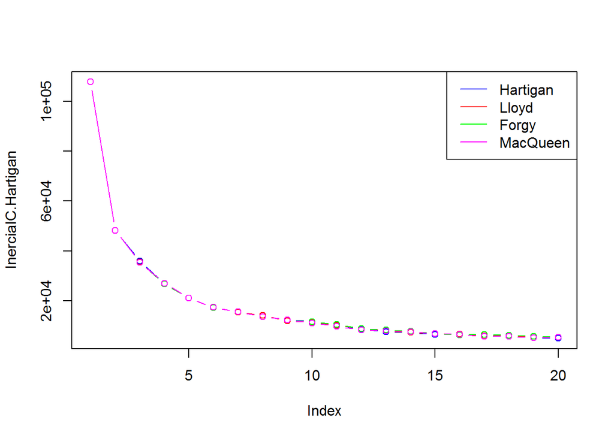

```r
datos <- read.csv("DJTable.csv",header=TRUE, sep=";", dec=".", row.names=1)

#Declaracion
InerciaIC.Hartigan<-rep(0,20)
InerciaIC.Lloyd<-rep(0,20)
InerciaIC.Forgy<-rep(0,20)
InerciaIC.MacQueen<-rep(0,20)

#Variacion K
for(k in 1:20) {
  grupos<-kmeans(datos,k,iter.max=2000,nstart=5,algorithm = "Hartigan-Wong")
  InerciaIC.Hartigan[k]<-grupos$tot.withinss
  grupos<-kmeans(datos,k,iter.max=2000,nstart=5,algorithm = "Lloyd")
  InerciaIC.Lloyd[k]<-grupos$tot.withinss
  grupos<-kmeans(datos,k,iter.max=2000,nstart=5,algorithm = "Forgy")
  InerciaIC.Forgy[k]<-grupos$tot.withinss
  grupos<-kmeans(datos,k,iter.max=2000,nstart=5,algorithm = "MacQueen")
  InerciaIC.MacQueen[k]<-grupos$tot.withinss
}


plot(InerciaIC.Hartigan,col="blue",type="b")
points(InerciaIC.Lloyd,col="red",type="b")
points(InerciaIC.Forgy,col="green",type="b")
points(InerciaIC.MacQueen,col="magenta",type="b")
legend("topright",legend = c("Hartigan","Lloyd","Forgy","MacQueen"),
       col = c("blue", "red","green","magenta"), lty = 1, lwd = 1)
```

Según el gráfico los algortimos se estabilizan en K=4 con estos parametros se obtendran 5 puntos de inicio y 2000 repeticiones de asginacion de cluster Es importante asignar un nstart bajo ya que de lo contrario se obtienen clusters vacios

# Punto B

Usando k = 3, nstart=5 y iter.max = 2000 en el metodo k−medias determine cual de los algoritmos “Hartigan-Wong”, “Lloyd”, “Forgy” y “MacQueen”funciona mejor para estos datos en el sentido de que minimizan la inercia intra–clases.

```r
#Declaracion
Hartigan<-0
Lloyd<-0
Forgy<-0
MacQueen<-0
# Re calculo de inercias
for(i in 1:50) {
  grupos<-kmeans(datos,3,iter.max=2000,nstart=5,algorithm = "Hartigan-Wong")
  Hartigan<-Hartigan+grupos$tot.withinss
  grupos<-kmeans(datos,3,iter.max=2000,nstart=5,algorithm = "Lloyd")
  Lloyd<-Lloyd+grupos$tot.withinss
  grupos<-kmeans(datos,3,iter.max=2000,nstart=5,algorithm = "Forgy")
  Forgy<-Forgy+grupos$tot.withinss
  grupos<-kmeans(datos,3,iter.max=2000,nstart=5,algorithm = "MacQueen")
  MacQueen<-MacQueen+grupos$tot.withinss
}
Hartigan/50
```

```
## [1] 35613.97
```

```r
Lloyd/50
```

```
## [1] 35565.76
```

```r
Forgy/50
```

```
## [1] 35550.2
```

```r
MacQueen/50
```

```
## [1] 35577.05
```

# Punto C

Repita el ejercicio anterior usando k = 3, nstart=1 y iter.max = 20. ¿Que se observa? ¿A que se debe la diferencia? ¿Cual resultado es mas creıble el del punto b) o el del punto c)?

```r
#Declaracion
Hartigan<-0
Lloyd<-0
Forgy<-0
MacQueen<-0
# Re calculo de inercias
for(i in 1:50) {
  grupos<-kmeans(datos,3,iter.max=20,nstart=1,algorithm = "Hartigan-Wong")
  Hartigan<-Hartigan+grupos$tot.withinss
  grupos<-kmeans(datos,3,iter.max=20,nstart=1,algorithm = "Lloyd")
  Lloyd<-Lloyd+grupos$tot.withinss
  grupos<-kmeans(datos,3,iter.max=20,nstart=1,algorithm = "Forgy")
  Forgy<-Forgy+grupos$tot.withinss
  grupos<-kmeans(datos,3,iter.max=20,nstart=1,algorithm = "MacQueen")
  MacQueen<-MacQueen+grupos$tot.withinss
}
Hartigan/50
```

```
## [1] 36639.77
```

```r
Lloyd/50
```

```
## [1] 36658
```

```r
Forgy/50
```

```
## [1] 36842.51
```

```r
MacQueen/50
```

```
## [1] 36507.99
```